# Detección de Anomalías - UNIR

Fernando Palomino, Mónica Hazeu, Xavier Castilla, Carles Serra

## 0) Preliminares

#### 0.1) Cargamos las librerías

```r
library(cluster)
library(CatEncoders)
library(car)
library(tidyverse)
library(mice)
library(corrplot)
library(RColorBrewer)
library(IsolationForest)
library(h2o)
library(solitude)
library(Metrics)
library(globals)
library(parallelly)
```

#### 0.2) Leer los datos

```r
creditCard <- read.csv("creditcardcsvpresent.csv")
dim(creditCard)
```

```
## [1] 3075   12
```

```r
head(creditCard)
```

|  | Merchant_id | Transaction.date | Average.Amount.transaction.day | Transaction_amount | Is.declined | Total.Number.of.declines.day | isForeignTransaction | isHighRiskCountry | Daily_chargeback_avg_amt | X6_month_avg_chbk_amt | X6.month_chbk_freq | isFradulent |
| --- | --- | --- | --- | --- | --- | --- | --- | --- | --- | --- | --- | --- |
| 1 | 3160040998 | NA | 100.0 | 3000.0 | N | 5 | Y | Y | 0 | 0.0 | 0 | Y |
| 2 | 3160040998 | NA | 100.0 | 4300.0 | N | 5 | Y | Y | 0 | 0.0 | 0 | Y |
| 3 | 3160041896 | NA | 185.5 | 4823.0 | Y | 5 | N | N | 0 | 0.0 | 0 | Y |
| 4 | 3160141996 | NA | 185.5 | 5008.5 | Y | 8 | N | N | 0 | 0.0 | 0 | Y |
| 5 | 3160241992 | NA | 500.0 | 26000.0 | N | 0 | Y | Y | 800 | 677.2 | 6 | Y |
| 6 | 3160241992 | NA | 500.0 | 27000.0 | N | 0 | Y | Y | 800 | 677.2 | 6 | Y |

[output not shown]

Tenemos 12 variables de 3075 instancias cada una.

Veamos los valores nulos:

```r
sum(is.na(creditCard))
```

```
## [1] 3075
```

Vemos que hay justamente los mismos valores faltantes que instancias de una variable. Si analizamos los datos, vemos que Transaction.date es una columna contodos los valores nulos:

```r
sum(is.na(creditCard$Transaction.date))
```

```
## [1] 3075
```

Por ello, la eliminamos de nuestro dataset.

```r
creditCard=creditCard%>%select(-Transaction.date)
```

Y veamos que no hay más datos faltantes:

```r
sum(is.na(creditCard))
```

```
## [1] 0
```

También vamos a eliminar la variable de Merchant_id porque no aporta nada de valor a nuestro dataset.

```r
creditCard=creditCard%>%select(-Merchant_id)
```

Hecho esto, vamos a separar las variables categóricas de las numéricas:

```r
str(creditCard)
```

```
## 'data.frame':    3075 obs. of  10 variables:
##  $ Average.Amount.transaction.day: num  100 100 186 186 500 ...
##  $ Transaction_amount            : num  3000 4300 4823 5008 26000 ...
##  $ Is.declined                   : chr  "N" "N" "Y" "Y" ...
##  $ Total.Number.of.declines.day  : int  5 5 5 8 0 0 0 20 20 20 ...
##  $ isForeignTransaction          : chr  "Y" "Y" "N" "N" ...
##  $ isHighRiskCountry             : chr  "Y" "Y" "N" "N" ...
##  $ Daily_chargeback_avg_amt      : int  0 0 0 0 800 800 900 0 0 0 ...
##  $ X6_month_avg_chbk_amt         : num  0 0 0 0 677 ...
##  $ X6.month_chbk_freq            : int  0 0 0 0 6 6 7 0 0 0 ...
##  $ isFradulent                   : chr  "Y" "Y" "Y" "Y" ...
```

```r
creditCard_numerico=creditCard%>%select(Average.Amount.transaction.day,
                                        Transaction_amount,
                                        Total.Number.of.declines.day,
                                        Daily_chargeback_avg_amt,
                                        X6_month_avg_chbk_amt,
                                        X6.month_chbk_freq )

creditCard_categorico= creditCard%>%select(Is.declined,
                                           isForeignTransaction,
                                           isHighRiskCountry,
                                           isFradulent)
```

## 1) Análisis descriptivo de los datos:

#### 1.1) De las variables numéricas hallar datos estadísticos: máximo, mínimo, media, mediana y cuartiles

Usemos la función summary para obtener estos datos estadísticos.

```r
summary(creditCard_numerico)
```

```
##  Average.Amount.transaction.day Transaction_amount Total.Number.of.declines.day
##  Min.   :   4.011               Min.   :     0     Min.   : 0.0000
##  1st Qu.: 269.788               1st Qu.:  2409     1st Qu.: 0.0000
##  Median : 502.550               Median :  6699     Median : 0.0000
##  Mean   : 515.027               Mean   :  9876     Mean   : 0.9574
##  3rd Qu.: 765.273               3rd Qu.: 14423     3rd Qu.: 0.0000
##  Max.   :2000.000               Max.   :108000     Max.   :20.0000
##  Daily_chargeback_avg_amt X6_month_avg_chbk_amt X6.month_chbk_freq
##  Min.   :  0.00           Min.   :  0.00        Min.   :0.0000
##  1st Qu.:  0.00           1st Qu.:  0.00        1st Qu.:0.0000
##  Median :  0.00           Median :  0.00        Median :0.0000
##  Mean   : 55.74           Mean   : 40.02        Mean   :0.3919
##  3rd Qu.:  0.00           3rd Qu.:  0.00        3rd Qu.:0.0000
##  Max.   :998.00           Max.   :998.00        Max.   :9.0000
```

Vemos que salvo las variables Average.Amount.transaction.day y Transaction_amount, parece que el resto de variables toman valores muy extremos, ya que los cuartiles son 0. Para visualizar esto, representemos estos valores numéricos con histogramas.

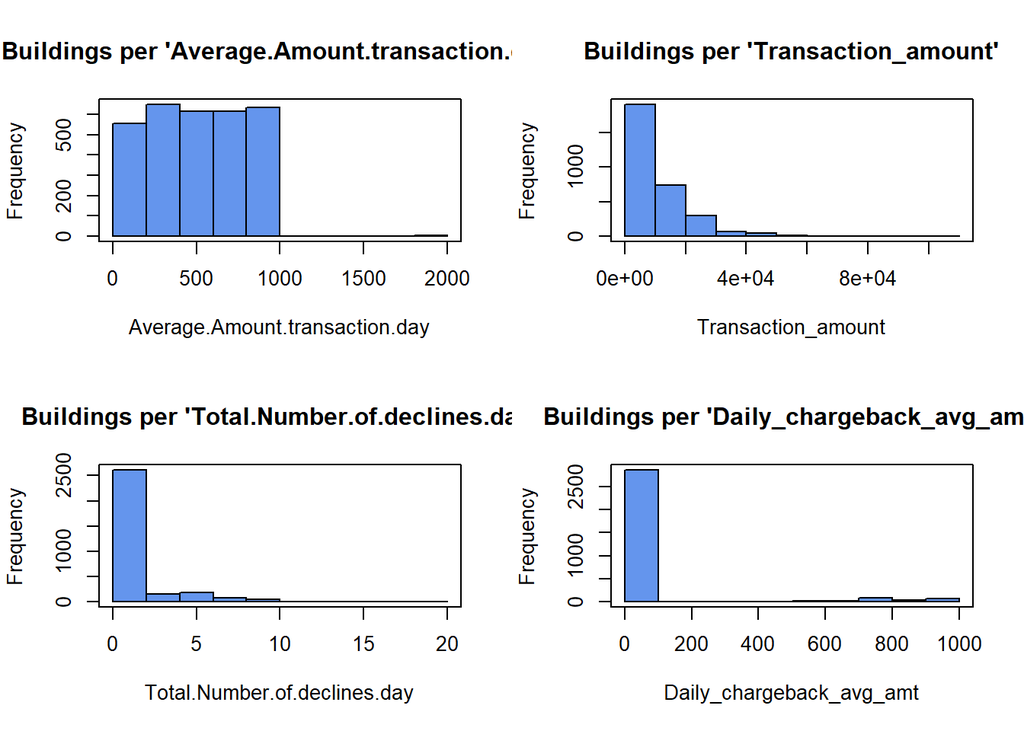

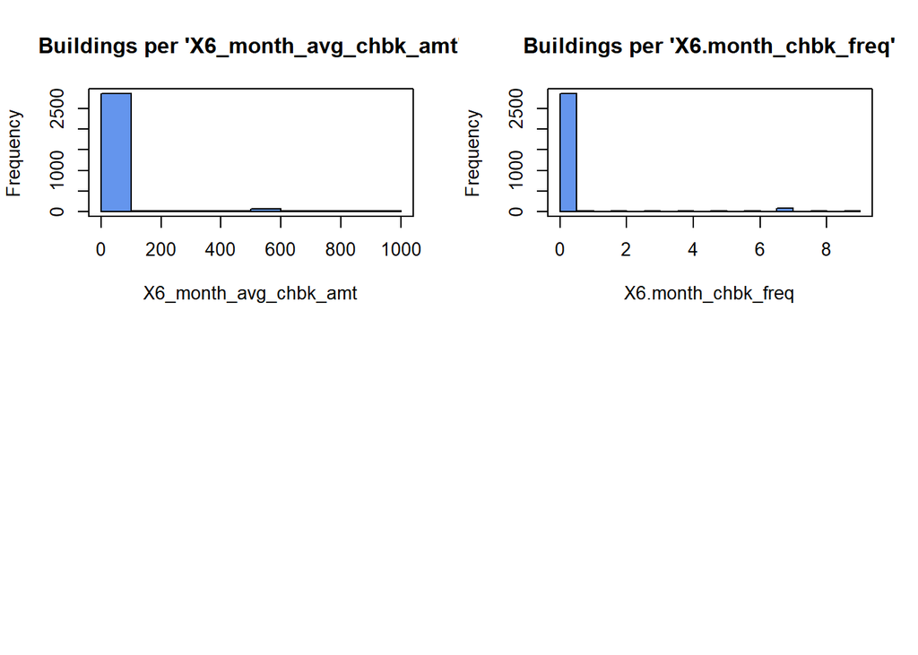

```r
get_histogram <- function(index, data) {
    var_name <- names(data)[index]
    hist(data[,index], main = paste0("Buildings per '", var_name, "'"), xlab = var_name, col = "cornflowerblue")
    box()
}

options(repr.plot.width = 10, repr.plot.height = 15, repr.plot.res = 100)
par(mfrow = c(2, 2))
dummy <- lapply(1:6, get_histogram, creditCard_numerico)
```

Y efectivamente podemos ver que la gran mayoria de los datos se agrupan en los primeros intervalos. Podemos empezar a pensar que algunos de estos datos más elevados podrán ser considerados outliers.

#### 1.2)De las variables categóricas, listar las diferentes categorías y hallar la frecuencia de cada una de ellas.

Pasemos estas variables a factores y veamos las frecuencias.

```r
creditCard_categorico=creditCard_categorico%>%mutate_if(is.character,as.factor)
summary(creditCard_categorico)
```

```
##  Is.declined isForeignTransaction isHighRiskCountry isFradulent
##  N:3018      N:2369               N:2870            N:2627
##  Y:  57      Y: 706               Y: 205            Y: 448
```

Representemos estos datos con diagramas de barras:

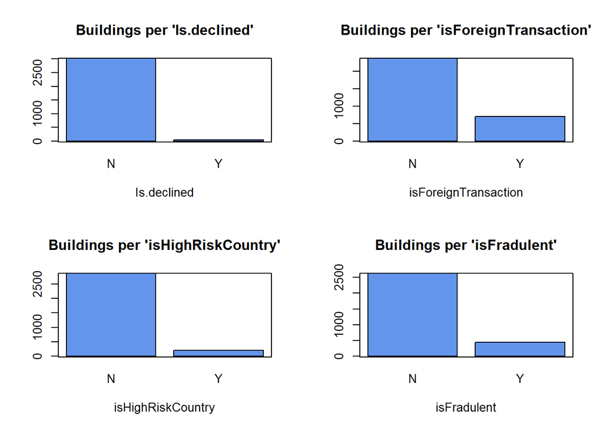

```r
get_bar_plot <- function(index, data) {
    counts <- table(data[,index])
    var_name <- names(data)[index]
    barplot(counts, main = paste0("Buildings per '", var_name, "'"), xlab = var_name, col = "cornflowerblue")
    box()
}

options(repr.plot.width = 2, repr.plot.height = 10, repr.plot.res = 100)
par(mfrow = c(2,2))
dummy <- lapply(1:4, get_bar_plot, creditCard_categorico)
```

Vemos que suele haber más datos “N” que “Y”, aunque fuera de contexto esto no aporta mucha información. Con excepción de isFraudulent, que el interés reside en esos valores “Y”. De hecho, veamos cuantos datos fraudulentos tenemos:

```r
table(creditCard_categorico$isFradulent)
```

```
##
##    N    Y
## 2627  448
```

Por tanto suponemos que tenemos 448 anomalías.

#### 1.3) Crear la matriz de correlaciones con las columnas numéricas

Veamos la correlación entre las variables numéricas:

```r
cor(creditCard_numerico)
```

```
##                                Average.Amount.transaction.day
## Average.Amount.transaction.day                    1.000000000
## Transaction_amount                                0.587110977
## Total.Number.of.declines.day                     -0.009681879
## Daily_chargeback_avg_amt                          0.060428849
## X6_month_avg_chbk_amt                             0.060284307
## X6.month_chbk_freq                                0.071849191
##                                Transaction_amount Total.Number.of.declines.day
## Average.Amount.transaction.day          0.5871110                 -0.009681879
## Transaction_amount                      1.0000000                  0.259308672
## Total.Number.of.declines.day            0.2593087                  1.000000000
## Daily_chargeback_avg_amt                0.2522981                  0.094834098
## X6_month_avg_chbk_amt                   0.2596628                  0.081137821
## X6.month_chbk_freq                      0.2976227                  0.085027707
##                                Daily_chargeback_avg_amt X6_month_avg_chbk_amt
## Average.Amount.transaction.day               0.06042885            0.06028431
## Transaction_amount                           0.25229808            0.25966282
## Total.Number.of.declines.day                 0.09483410            0.08113782
## Daily_chargeback_avg_amt                     1.00000000            0.95366343
## X6_month_avg_chbk_amt                        0.95366343            1.00000000
## X6.month_chbk_freq                           0.88461078            0.85133858
##                                X6.month_chbk_freq
## Average.Amount.transaction.day         0.07184919
## Transaction_amount                     0.29762268
## Total.Number.of.declines.day           0.08502771
## Daily_chargeback_avg_amt               0.88461078
## X6_month_avg_chbk_amt                  0.85133858
## X6.month_chbk_freq                     1.00000000
```

Veámoslo ahora gráficamente:

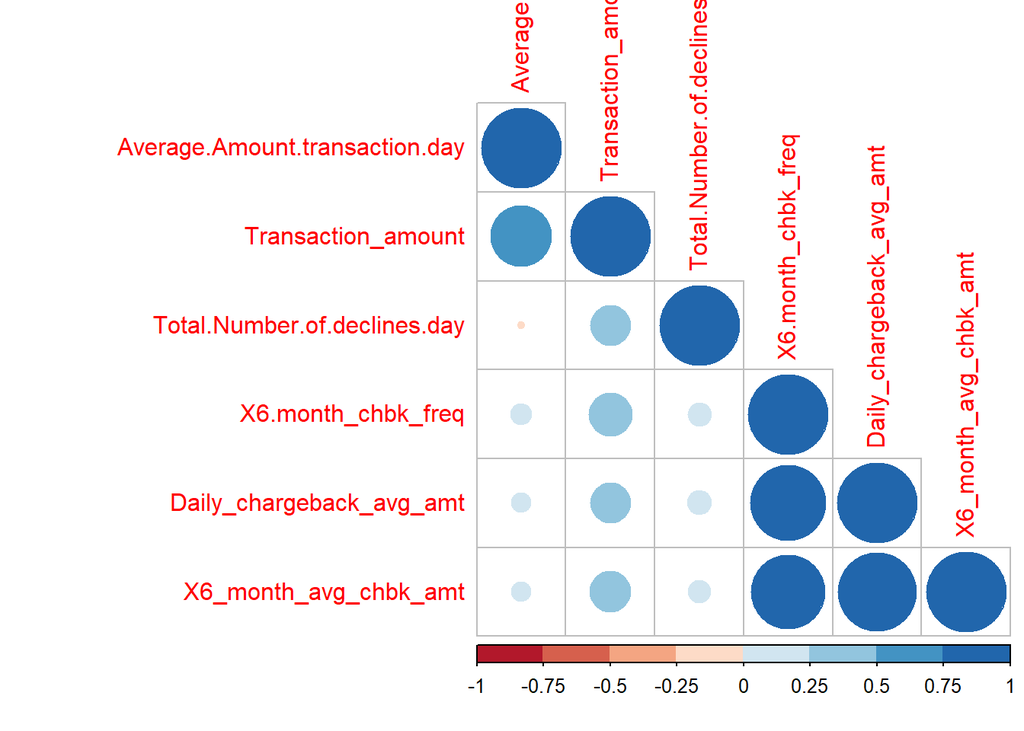

```r
matriz=cor(creditCard_numerico)
corrplot(matriz, method="circle", type="lower", order="hclust",
         col=brewer.pal(n=8, name="RdBu"))
```

#### 1.4) Encontrar las correlaciones más altas, que superen el 0.75

```r
sum(cor(creditCard_numerico)>0.75 & cor(creditCard_numerico)!=1)/2
```

```
## [1] 3
```

Hay 3 variables que están muy correladas, estas son: Daily_chargeback_avg_amt - X6.month_chbk_freq (88% correlación) X6_month_avg_chbk_amt - X6.month_chbk_freq (85% correlación) X6_month_avg_chbk_amt - Daily_chargeback_avg_amt (95% correlación)

Estas correlaciones son superiores al 75%, así que se puede discutir en eliminarlas. El resto no superan el 75% así que nos las eliminaremos.

#### 1.5) Revisar las correlaciones más altas y decidir si eliminar o no la columna

Se van a eliminar la variable X6_month_avg_chbk_amt y X6.month_chbk_freq ya que se consideran más relevantes los datos diarios para la predicción de fraudes que una media con menos picos a largo plazo.

```r
creditCard_numerico=creditCard_numerico%>%select(-X6_month_avg_chbk_amt,
                                                 -X6.month_chbk_freq)
```

Y por último unamos en un dataset este análisis que hemos hecho.

Será interesante que cambiemos estos valores “Y” y “N” por valores 1 y 0, para poder escalarlos con posterioridad y usarlos en el clústering. No olvidemos pasar los valores categóricos a factores. Por tanto:

```r
creditCard_categorico_10 <- creditCard_categorico %>%
      mutate(Is.declined = ifelse(Is.declined == "Y",1,0),
             isForeignTransaction = ifelse(isForeignTransaction == "Y",1,0),
             isHighRiskCountry= ifelse(isHighRiskCountry == "Y",1,0),
             isFradulent= ifelse(isFradulent == "Y",1,0))

creditCard_categorico_10$Is.declined=as.factor(creditCard_categorico_10$Is.declined)
creditCard_categorico_10$isForeignTransaction=
  as.factor(creditCard_categorico_10$isForeignTransaction)
creditCard_categorico_10$isHighRiskCountry=
  as.factor(creditCard_categorico_10$isHighRiskCountry)
creditCard_categorico_10$isFradulent=
  as.factor(creditCard_categorico_10$isFradulent)
```

Escalemos las variables numéricas y unámoslas con las variables categóricas.

```r
creditCard_numerico_escalado=as.data.frame(lapply(creditCard_numerico,scale))
creditCard_final=cbind(creditCard_numerico_escalado, creditCard_categorico_10)
```

Vamos a separar tambien este dataset del is.Fraudulent, que será el que queramos predecir. (Si es fraudulento, en principio, es anomalía). Por tanto:

```r
creditCard_final_Y=creditCard_final%>%select(isFradulent)
creditCard_final_no_Y=creditCard_final%>%select(-isFradulent)
```

## 2) Cluster o agrupamiento

#### 2.1) Crear al menos dos modelos con grupos diferentes para poder compararlos

Vamos a crear dos modelos, uno con 5 clusters y otro con 10.

```r
set.seed(1)
num.clusters1=5

modelo.kmeans1 <- kmeans(creditCard_final, num.clusters1)
asignaciones.clustering.kmeans1 <- modelo.kmeans1$cluster
centroides1 <- modelo.kmeans1$centers

num.clusters2=10
modelo.kmeans2 <- kmeans(creditCard_final, num.clusters2)
asignaciones.clustering.kmeans2 <- modelo.kmeans2$cluster
centroides2 <- modelo.kmeans2$centers
```

#### 2.2) Imprima los centroides de los grupos de los dos modelos creados y comente los resultados.

```r
centroides1
```

```
##   Average.Amount.transaction.day Transaction_amount
## 1                    -0.09072454          0.4663439
## 2                     0.64168338         -0.1525433
## 3                     1.11182535          1.4333352
## 4                     0.18140996          0.8476598
## 5                    -0.92589768         -0.6238727
##   Total.Number.of.declines.day Daily_chargeback_avg_amt Is.declined
## 1                    2.5190463               -0.2636341 0.016556291
## 2                   -0.3709399               -0.2684711 0.000000000
## 3                   -0.1755610               -0.2193608 0.005000000
## 4                    0.3407399                3.6626645 0.231527094
## 5                   -0.3325343               -0.2630185 0.002546689
##   isForeignTransaction isHighRiskCountry isFradulent
## 1            0.4900662       0.271523179 0.572847682
## 2            0.1733871       0.003024194 0.006048387
## 3            0.3350000       0.140000000 0.222500000
## 4            0.3152709       0.142857143 0.650246305
## 5            0.1595925       0.029711375 0.040747029
```

```r
centroides2
```

```
##    Average.Amount.transaction.day Transaction_amount
## 1                      1.26973125        -0.34397407
## 2                      0.55075718         0.44286214
## 3                      0.09684414         0.68741638
## 4                     -0.50197027        -0.41423720
## 5                     -0.57945386        -0.23643283
## 6                     -1.31932365        -0.80965321
## 7                      1.17276536         1.30288778
## 8                      1.24278076         3.12001960
## 9                      0.35274278        -0.59570020
## 10                    -0.36283884        -0.01588116
##    Total.Number.of.declines.day Daily_chargeback_avg_amt Is.declined
## 1                    -0.3330271               -0.2656542 0.000000000
## 2                    -0.3895503               -0.2656841 0.000000000
## 3                     0.3133253                3.6705758 0.216494845
```

[output cut: 18 more lines]

Al aumentar el número de clústers, lo que sucede es que los centroides cambian de posición, para así ajustarse más a los datos de entrada.

Si los representamos gráficamente:

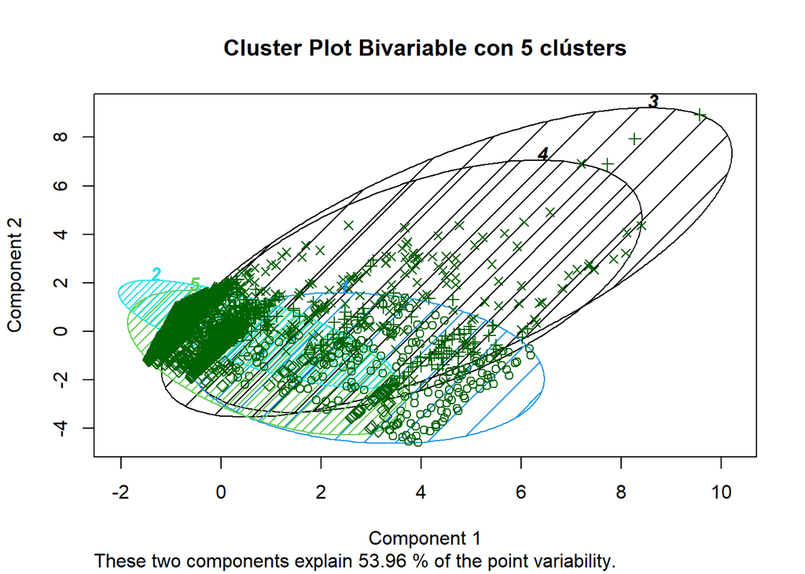

```r
clusplot(creditCard_final,
         modelo.kmeans1$cluster,
         color=TRUE,
         col.clus=c(1:5)[unique(modelo.kmeans1$cluster)],
         shade=TRUE,
         labels=4,
         lines=0,
         main = "Cluster Plot Bivariable con 5 clústers")
```

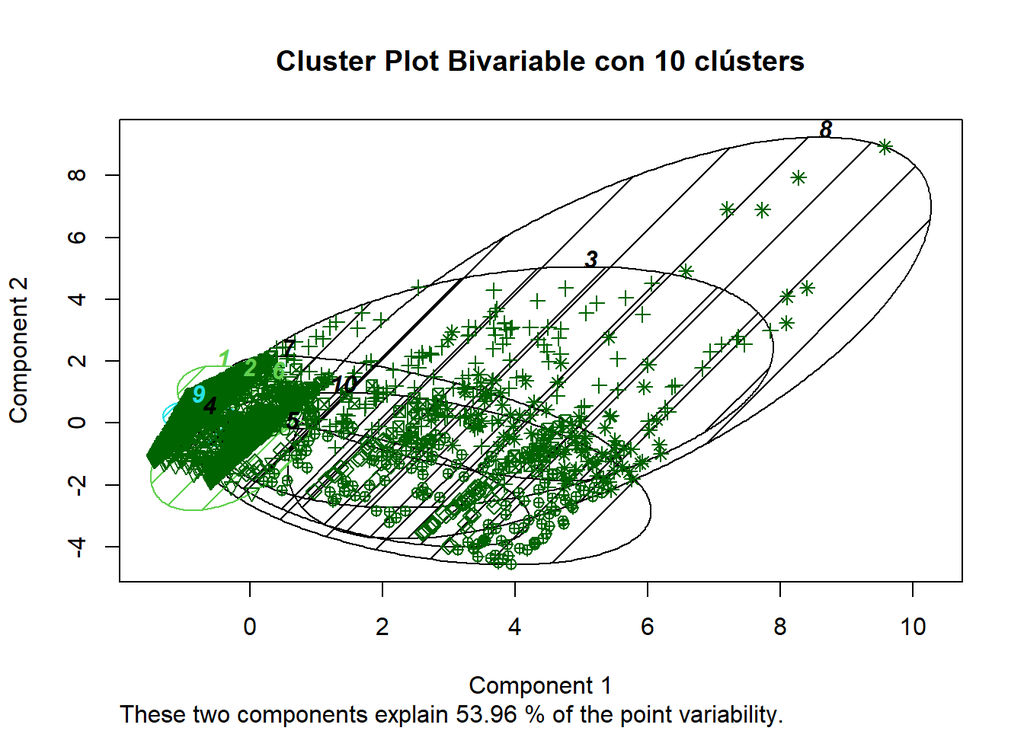

```r
clusplot(creditCard_final,
         modelo.kmeans2$cluster,
         color=TRUE,
         col.clus=c(1:5)[unique(modelo.kmeans2$cluster)],
         shade=TRUE,
         labels=4,
         lines=0,
         main = "Cluster Plot Bivariable con 10 clústers")
```

Lo interesante sería ver qué valores distan más del clúster al que pertenecen, para poder ser así clasificados como outliers de ese clúster.